# Eric_Hirsch_624_Homework_6

The plot becomes denser with decreasing levels of phi.

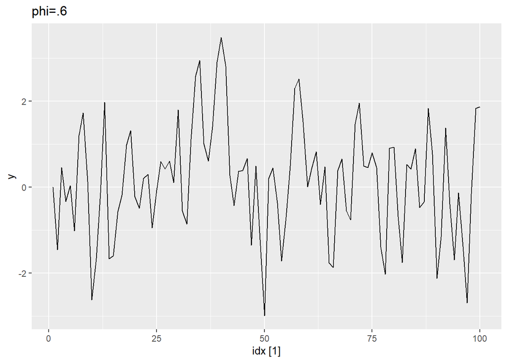

```r
autoplot(sim2) +labs(title="phi=.6")
```

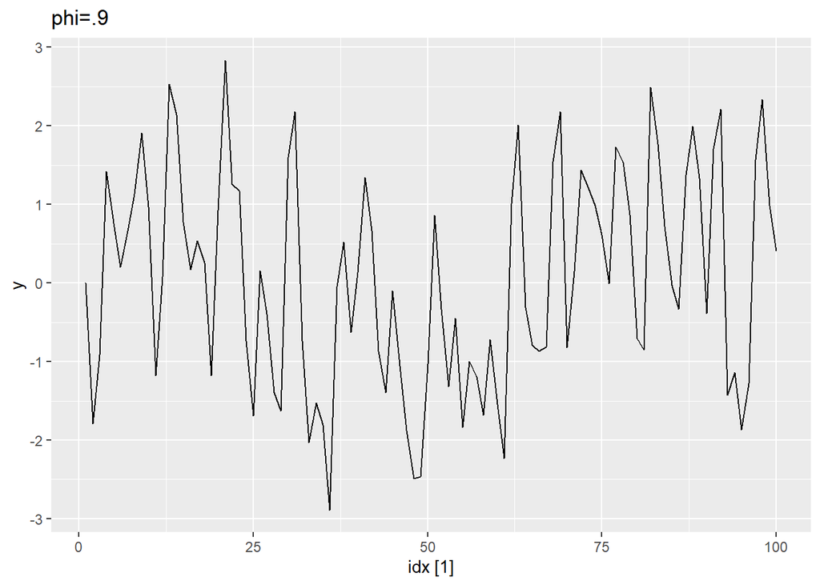

```r
y <- numeric(100)
e <- rnorm(100)
for(i in 2:100)
  y[i] <- e[i] + .9*e[i-1]
sim2 <- tsibble(idx = seq_len(100), y = y, index = idx)

autoplot(sim2) +labs(title="phi=.9")
```

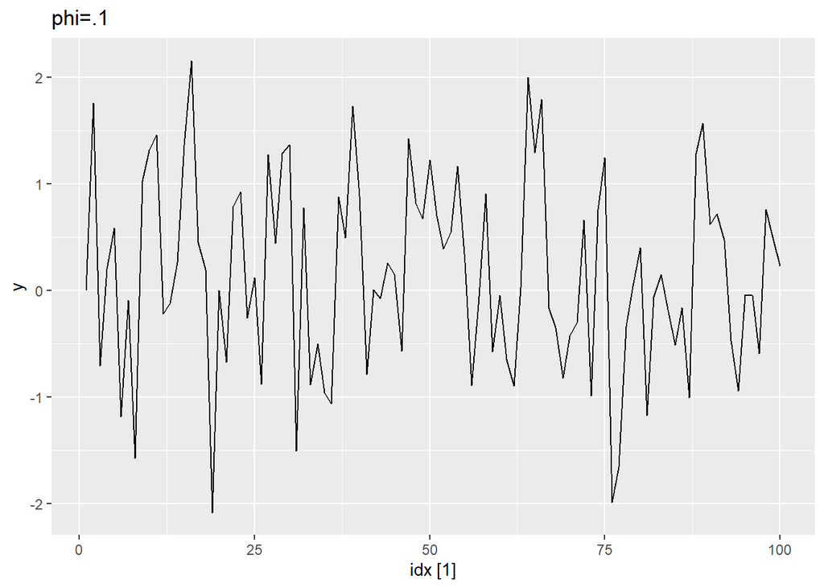

```r
y <- numeric(100)
e <- rnorm(100)
for(i in 2:100)
  y[i] <- e[i] + .1*e[i-1]
sim2 <- tsibble(idx = seq_len(100), y = y, index = idx)

autoplot(sim2) +labs(title="phi=.1")
```

__*9.6e Generate data from an ARMA(1,1) model.__*

```r
y <- numeric(100)
e <- rnorm(100)
for(i in 2:100)
  y[i] <- e[i] + .6*e[i-1] + 0.6*y[i-1]
sim3 <- tsibble(idx = seq_len(100), y = y, index = idx)
```

*9.6f Generate data from an AR(2) model.*

```r
y <- numeric(100)
e <- rnorm(100)
for(i in 3:100)
  y[i] <- e[i] -.8*y[i-1] + .3*y[i-2]
sim4 <- tsibble(idx = seq_len(100), y = y, index = idx)
```

*9.6g Graph the latter two series and compare them.*

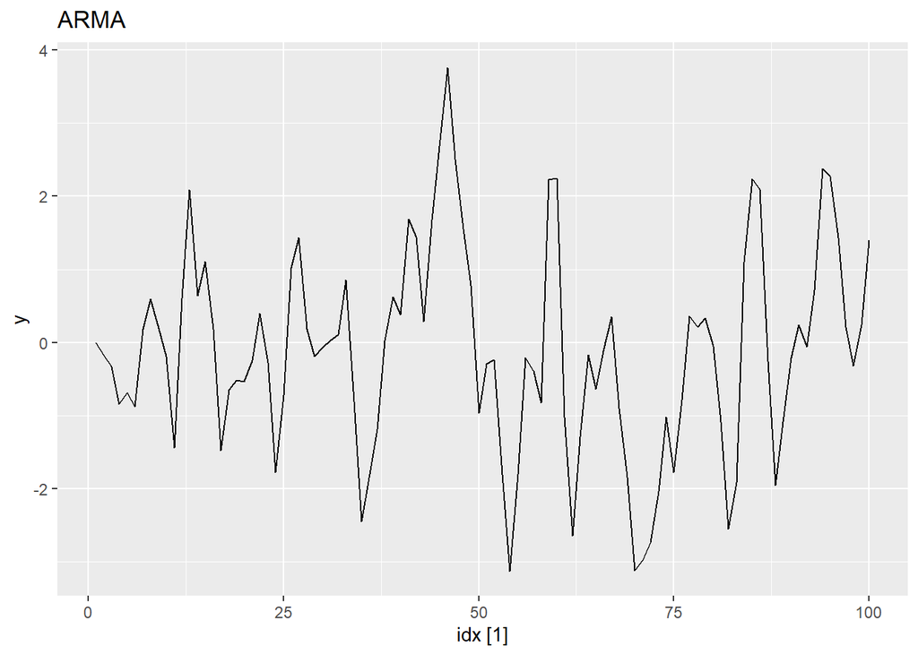

```r
autoplot(sim3) + labs(title="ARMA")
```

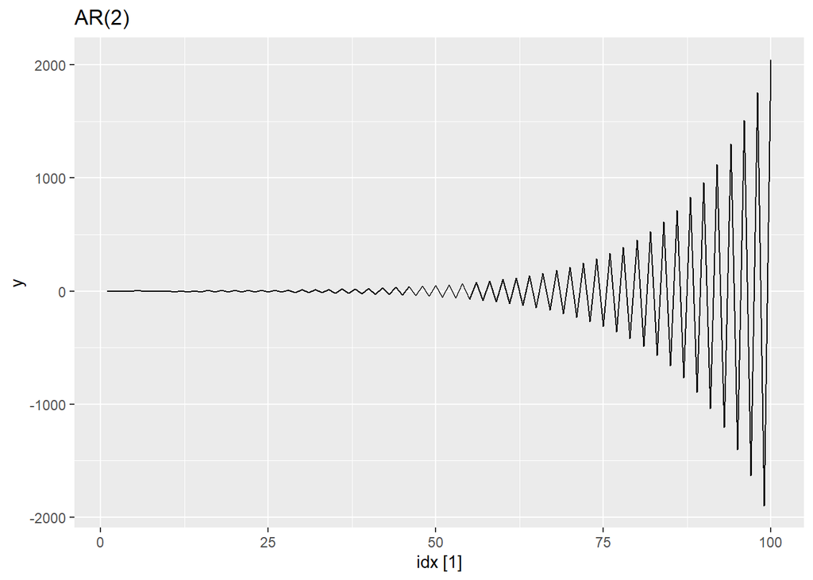

```r
autoplot(sim4) + labs(title="AR(2)")
```

*9.7 Consider aus_airpassengers, the total number of passengers (in millions) from Australian air carriers for the period 1970-2011.*

__9.7a Use ARIMA() to find an appropriate ARIMA model. What model was selected. Check that the residuals look like white noise. Plot forecasts for the next 10 periods.*__

```r
fit <- aus_airpassengers %>%
  model(ARIMA(Passengers))

report(fit)
```

```
## Series: Passengers
## Model: ARIMA(0,2,1)
##
## Coefficients:
##           ma1
##       -0.8963
## s.e.   0.0594
##
## sigma^2 estimated as 4.308:  log likelihood=-97.02
## AIC=198.04   AICc=198.32   BIC=201.65
```

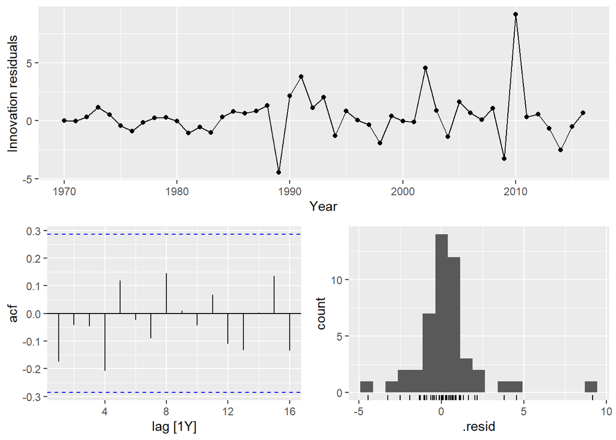

```r
fit %>% gg_tsresiduals()
```

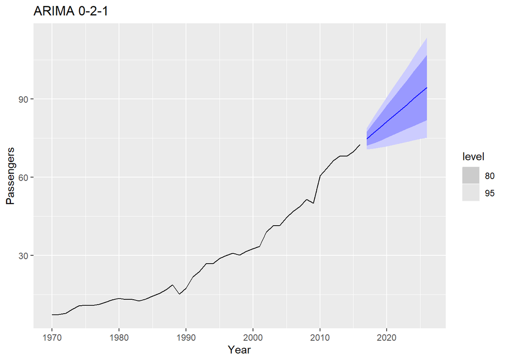

```r
fc <- fit %>%
  forecast(h=10)

fc %>% autoplot(aus_airpassengers) + labs(title = "ARIMA 0-2-1")
```

*9.7c Plot forecasts from an ARIMA(0,1,0) model with drift and compare these to part a.*

```r
fit2 <- aus_airpassengers %>%
  model(ARIMA(Passengers ~ pdq(0,1,0)))

report(fit2)
```

```
## Series: Passengers
## Model: ARIMA(0,1,0) w/ drift
##
## Coefficients:
##       constant
##         1.4191
## s.e.    0.3014
##
## sigma^2 estimated as 4.271:  log likelihood=-98.16
## AIC=200.31   AICc=200.59   BIC=203.97
```

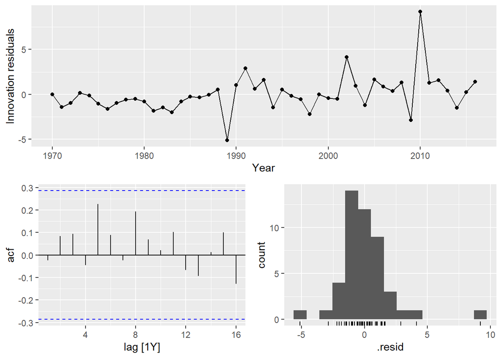

```r
fit2 %>% gg_tsresiduals()
```

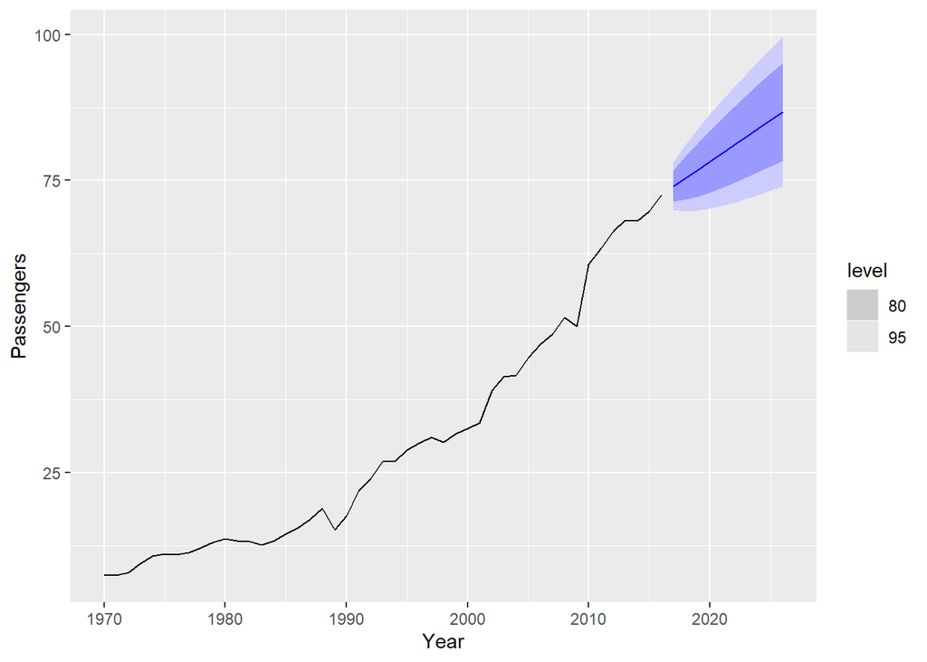

```r
fc2 <- fit2 %>%
  forecast(h=10)

fc2 %>% autoplot(aus_airpassengers) + labs(labs(title = "ARIMA 0-1-0"))
```

*9.7d Plot forecasts from an ARIMA(2,1,2) model with drift and compare these to parts a and c. Remove the constant and see what happens.*

```r
fit2 <- aus_airpassengers %>%
  model(ARIMA(Passengers ~ pdq(2,1,2), include.mean=FALSE))

report(fit2)
```

```
## Series: Passengers
## Model: NULL model
## NULL model
```

```r
#fit2 %>% gg_tsresiduals()

#fc2 <- fit2 %>%
#  forecast(h=10)

#fc2 %>% autoplot(aus_airpassengers) + labs(labs(title = "ARIMA 0-1-0"))


fit3 <- aus_airpassengers %>%
  model(ARIMA(Passengers ~ pdq(2,1,2)))

report(fit3)
```

```
## Series: Passengers
## Model: NULL model
## NULL model
```

```r
#fit3 %>% gg_tsresiduals()

#fc3 <- fit3 %>%
#  forecast(h=10)

#fc3 %>% autoplot(aus_airpassengers) + labs(title = + labs(title = "ARIMA 2-1-2, no drift"))
```

For the United States GDP series (from global_economy):

a.if necessary, find a suitable Box-Cox transformation for the data;

```r
tsUSA <- global_economy %>%
  filter(Country=="United States")

tsUSA <- tsUSA |>  mutate(GDP=box_cox(GDP, Get_lambda(tsUSA, "GDP")))
```

b, fit a suitable ARIMA model to the transformed data using ARIMA();

AIC 657

```r
fit2 <- tsUSA %>%
  model(ARIMA(GDP))

report(fit2)
```

```
## Series: GDP
## Model: ARIMA(1,1,0) w/ drift
##
## Coefficients:
##          ar1  constant
##       0.4586  118.1822
## s.e.  0.1198    9.5047
##
## sigma^2 estimated as 5479:  log likelihood=-325.32
## AIC=656.65   AICc=657.1   BIC=662.78
```

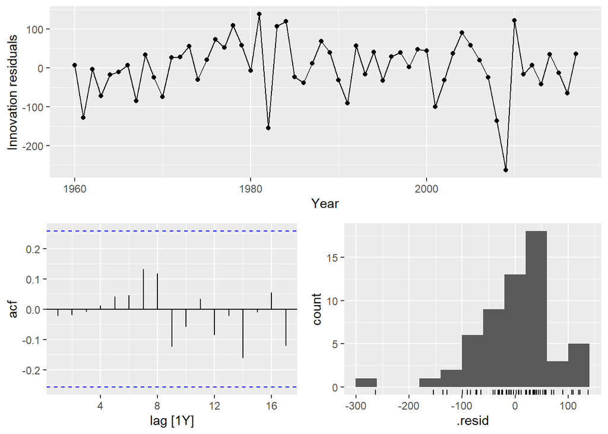

```r
fit2 %>% gg_tsresiduals()
```

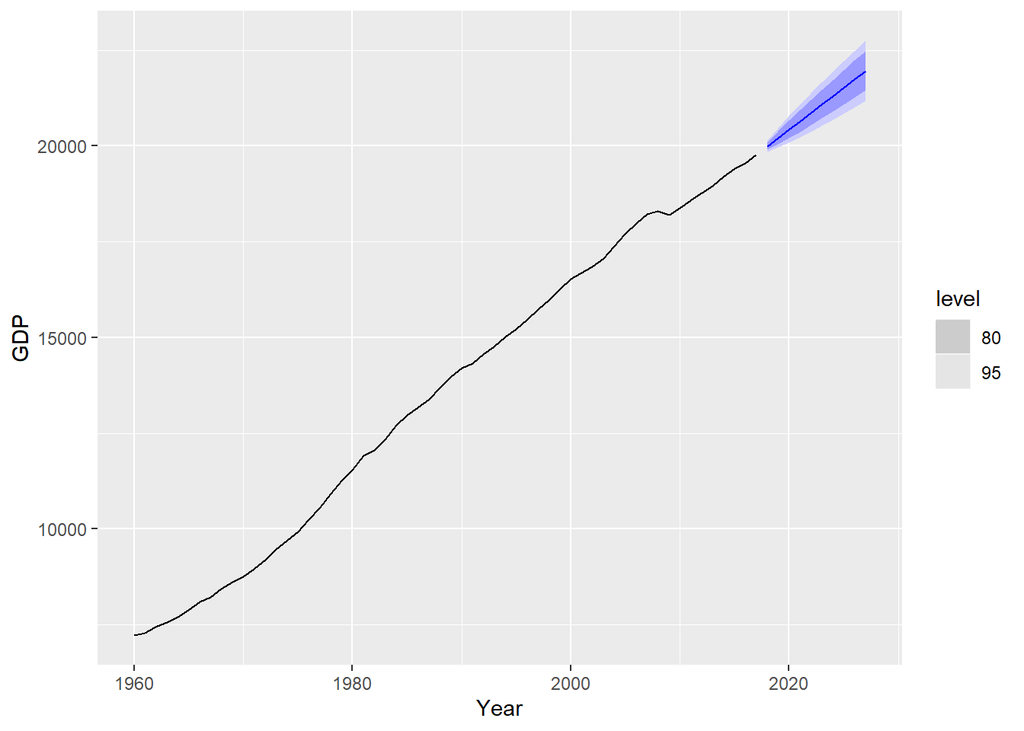

```r
fc2 <- fit2 %>%
  forecast(h=10)

fc2 %>% autoplot(tsUSA) + labs(labs(title = "ARIMA 1-1-0"))
```

3. try some other plausible models by experimenting with the orders chosen:

1-1-1, 1-2-0 <- 659, 656

```r
fit2 <- tsUSA %>%
  model(ARIMA(GDP ~ pdq(1,1,1)))

report(fit2)
```

```
## Series: GDP
## Model: ARIMA(1,1,1) w/ drift
##
## Coefficients:
##          ar1      ma1  constant
##       0.4736  -0.0190  114.8547
## s.e.  0.2851   0.3286    9.3486
##
## sigma^2 estimated as 5580:  log likelihood=-325.32
## AIC=658.64   AICc=659.41   BIC=666.82
```

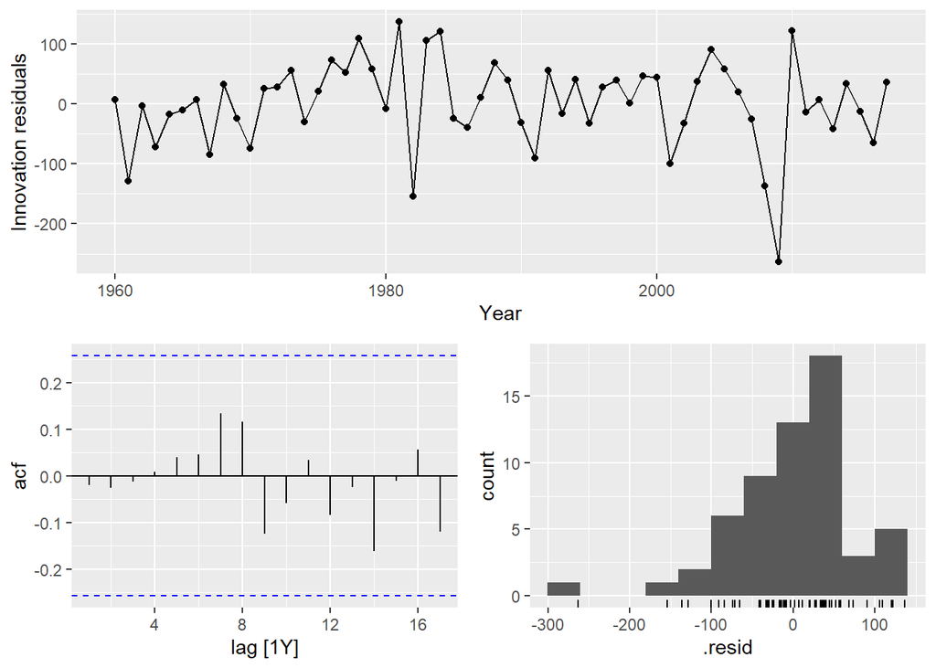

```r
fit2 %>% gg_tsresiduals()
```

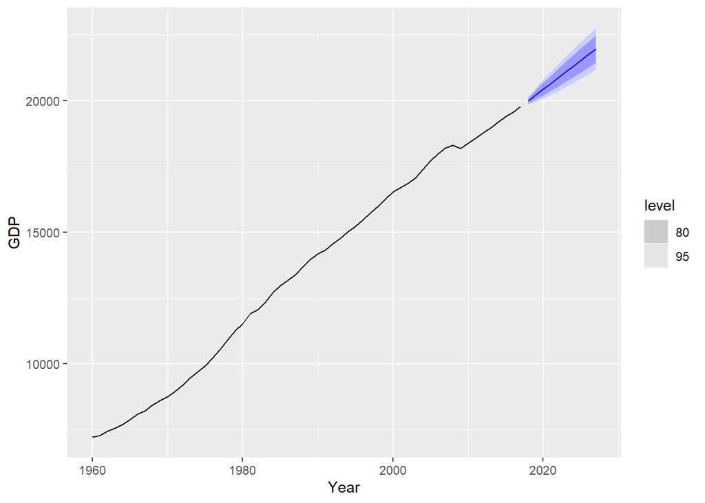

```r
fc2 <- fit2 %>%
  forecast(h=10)

fc2 %>% autoplot(tsUSA) + labs(labs(title = "ARIMA 1-1-1"))
```

```r
fit2 <- tsUSA %>%
  model(ARIMA(GDP ~ pdq(1,2,0)))

report(fit2)
```

```
## Series: GDP
## Model: ARIMA(1,2,0)
##
## Coefficients:
##           ar1
##       -0.2732
## s.e.   0.1289
##
## sigma^2 estimated as 6780:  log likelihood=-325.99
## AIC=655.99   AICc=656.22   BIC=660.04
```

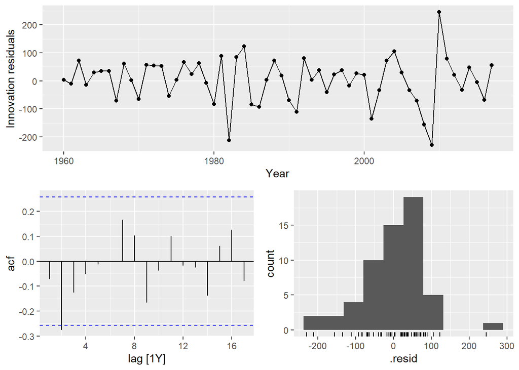

```r
fit2 %>% gg_tsresiduals()
```

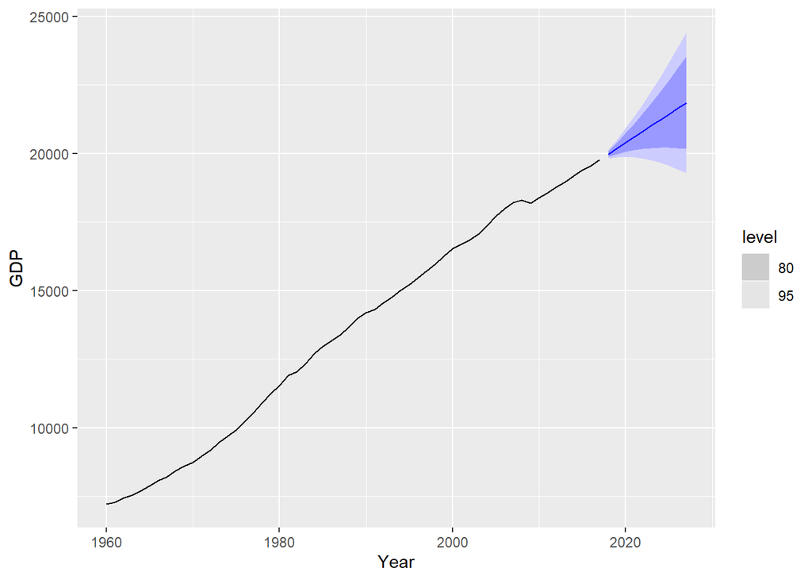

```r
fc2 <- fit2 %>%
  forecast(h=10)

fc2 %>% autoplot(tsUSA) + labs(labs(title = "ARIMA 1-2-0"))
```

4. choose what you think is the best model and check the residual diagnostics;
5. produce forecasts of your fitted model. Do the forecasts look reasonable?
6. compare the results with what you would obtain using ETS() (with no transformation).

```r
tsU<- global_economy %>%
  filter(Country=="United States")


fit2 <- tsU  %>% model(ETS(GDP ~ error("M") + trend("A") + season("N")))

report(fit2)
```

```
## Series: GDP
## Model: ETS(M,A,N)
##   Smoothing parameters:
##     alpha = 0.9990876
##     beta  = 0.5011949
##
##   Initial states:
##          l[0]        b[0]
##  448093333334 64917355687
##
##   sigma^2:  7e-04
##
##      AIC     AICc      BIC
## 3190.787 3191.941 3201.089
```

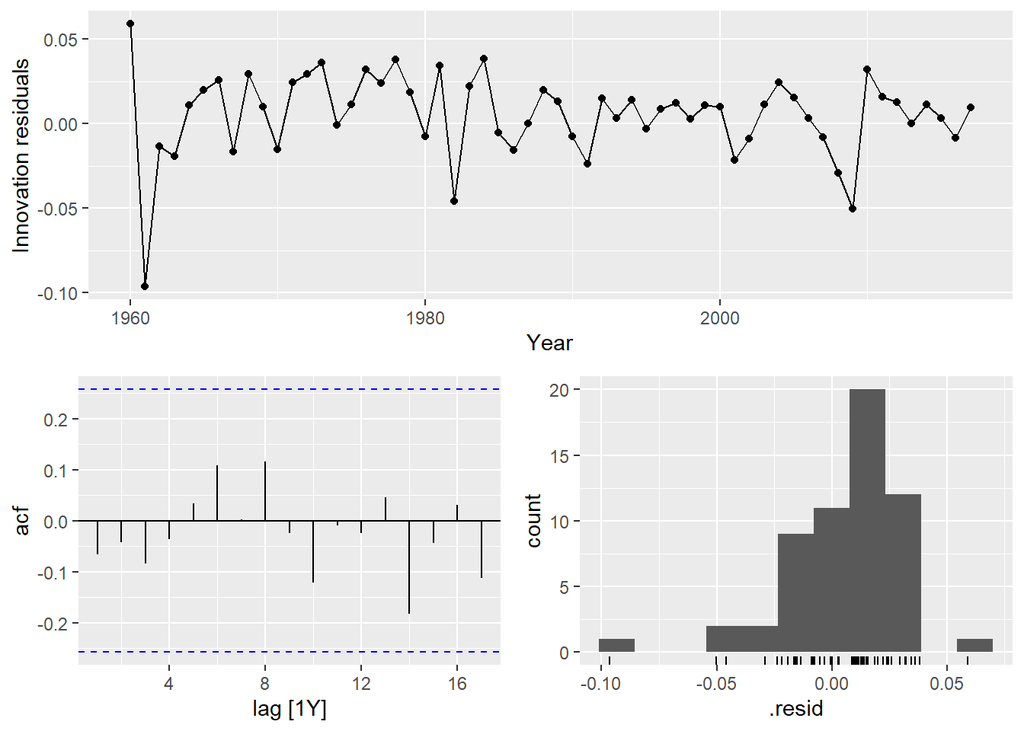

```r
fit2 %>% gg_tsresiduals()
```

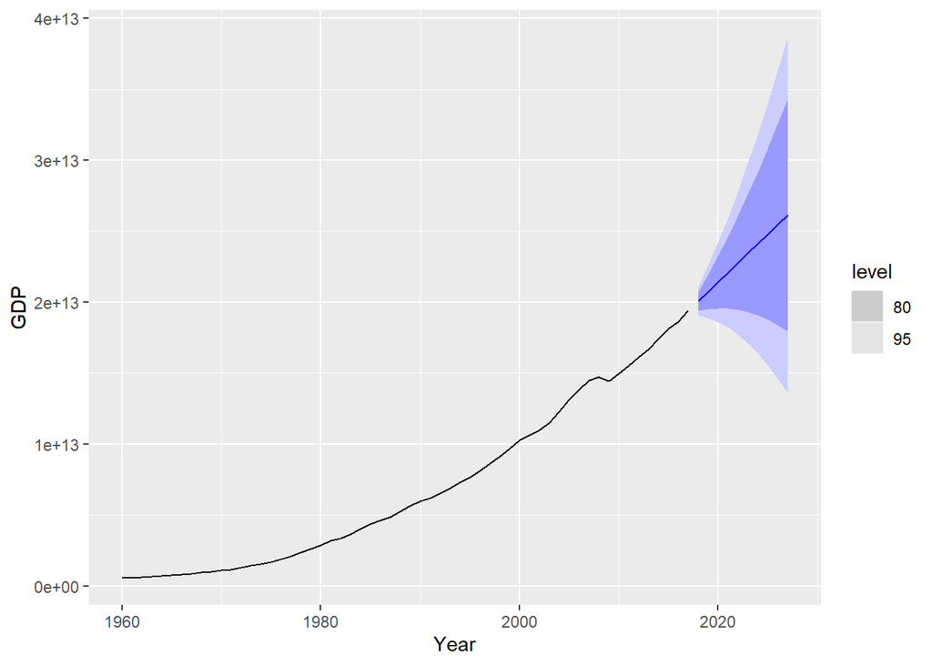

```r
fc2 <- fit2 %>%
  forecast(h=10)

fc2 %>% autoplot(tsU) + labs(labs(title = "ETS MAN"))
```